```python
import numpy as np
import matplotlib.pyplot as plt
import os

!pip install wget
if not os.path.exists('thinkdsp.py'):
    !python -m wget https://github.com/AllenDowney/ThinkDSP/raw/master/code/thinkdsp.py

from thinkdsp import decorate, read_wave, Spectrum, Wave

def serial_corr (wave, lag=1):
    N = len (wave)
    y1 = wave.ys[lag:]
    y2 = wave.ys[:N-lag]
    corr = np.corrcoef(y1, y2)[0, 1]
    return corr

def autocorr (wave):
    lags = range(len(wave.ys)//2)
    corrs = [serial_corr(wave, lag) for lag in lags]
    return lags, corrs
```

```
  Preparing metadata (setup.py) ... done

Saved under thinkdsp.py
```

# Упражнение 5.1

Блокнот Jupyter этой главы, chap05.ipynb, содержит приложение, в котором можно вычислить автокорреляции для различных lag. Оцените высоты тона вокального чирпа для нескольких времен начала сегмента.

```python
if not os.path.exists('28042__bcjordan__voicedownbew.wav'):
    !python -m wget https://github.com/AllenDowney/ThinkDSP/raw/master/code/28042__bcjordan__voicedownbew.wav
```

```
Saved under 28042__bcjordan__voicedownbew.wav
```

```python
from thinkdsp import read_wave

wave = read_wave('28042__bcjordan__voicedownbew.wav')
wave.normalize()
wave.make_audio()
```

[interactive chart not shown]

Посмотрим на 3 его сегмента:

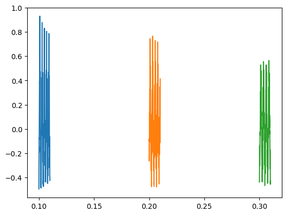

```python
duration = 0.01
segment1 = wave.segment(start=0.1, duration=duration)
segment1.plot()
segment2 = wave.segment(start=0.2, duration=duration)
segment2.plot()
segment3 = wave.segment(start=0.3, duration=duration)
segment3.plot()
```

А такаже вычислим lag:

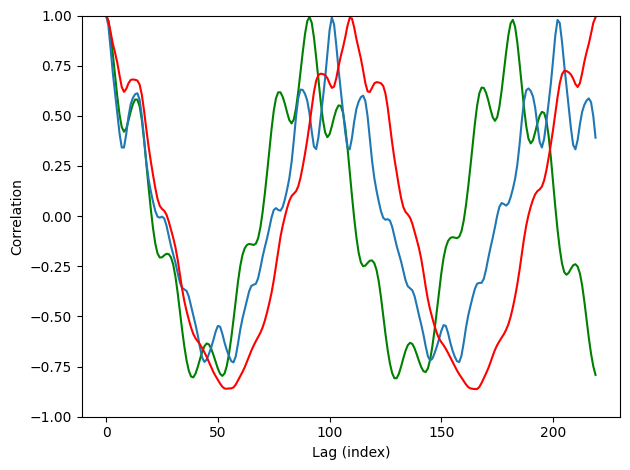

```python
lags1, corrs1 = autocorr(segment1)
plt.plot(lags1, corrs1, color='green')
decorate(xlabel='Lag (index)', ylabel='Correlation', ylim=[-1, 1])

lags2, corrs2 = autocorr(segment2)
plt.plot(lags2, corrs2)
decorate(xlabel='Lag (index)', ylabel='Correlation', ylim=[-1, 1])

lags3, corrs3 = autocorr(segment3)
plt.plot(lags3, corrs3, color='red')
decorate(xlabel='Lag (index)', ylabel='Correlation', ylim=[-1, 1])
```

Для оценки высоты тона используем автокорреляцию

```python
low, high = 50, 200
lag1 = np.array(corrs1[low:high]).argmax() + low

low, high = 50, 200
lag2 = np.array(corrs2[low:high]).argmax() + low

low, high = 50, 200
lag3 = np.array(corrs3[low:high]).argmax() + low

lag1,lag2, lag3
```

```
(91, 101, 109)
```

```python
period1 = lag1 / segment1.framerate
period2 = lag2 / segment2.framerate
period3 = lag3 / segment3.framerate
period1, period2, period3
```

```
(0.0020634920634920637, 0.002290249433106576, 0.002471655328798186)
```

```python
frequency1 = 1 / period1
frequency2 = 1 / period2
frequency3 = 1 / period3
frequency1, frequency2, frequency3
```

```
(484.6153846153846, 436.63366336633663, 404.5871559633028)
```

# Упражнение 5.2

Пример кода в chap05.ipynb показывает, как использовать автокорреляцию для оценки основной частоты периодического сигнала. Инкапсулируйте этот код в функцию, названную estimate_fundamental, и используйте ее для отслеживания высоты тона записанного звука.

Проверьте, насколько хорошо она работает, накладывая оценки высоты тона на спектрограмму записи.

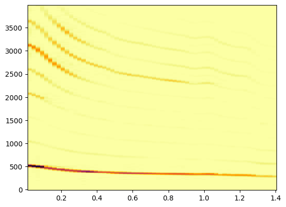

```python
wave.make_spectrogram(2048).plot(high=4000)
```

Создадим требуюмую функцию:

```python
def estimate_fundamental(segment, low=50, high=200):
  lags, corrs = autocorr(segment)
  lag = np.array(corrs[low:high]).argmax() + low
  period = lag / segment.framerate
  frequency = 1 / period
  return frequency
```

```python
estimate_fundamental(segment1)
```

```
484.6153846153846
```

Разделим на сегменты, чтобы провести оценку высоты тона на всей спектограмме

```python
duration = wave.duration
step = 0.02
start = 0
time = []
freq = []
while start + step < duration:
  time.append(start + step/2)
  freq.append(estimate_fundamental(wave.segment(start=start,duration=step)))
  start += step
```

Посторим новую спектограмму. Видим наложение.

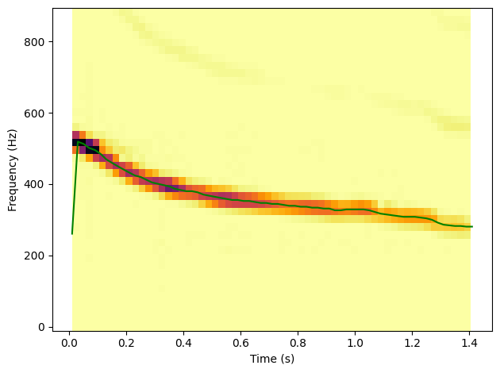

```python
wave.make_spectrogram(2048).plot(high=900)
plt.plot(time, freq, color='green')
decorate(xlabel='Time (s)', ylabel='Frequency (Hz)')
```

# Упржанение 5.3

Для упражнений в предыдущей главе были нужны исторические цены BitCoins, и надо было оценить спектр мощности изменения цен. Используя те же данные, вычислите автокорреляции цен в платежной системе Bitcoin. Быстро ли спадает автокорреляционная функция? Есть ли признаки периодичности процесса?

```python
if not os.path.exists('BTC_USD_2013_2021.csv'):
    !python -m wget https://github.com/DmitReiCat/SPBSTU-Telecom-Labs/raw/master/chap04/BTC_USD_2013_2021.csv
```

```
Saved under BTC_USD_2013_2021.csv
```

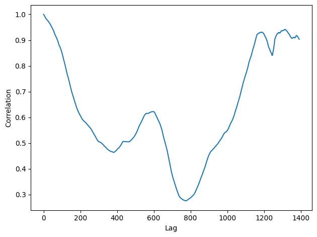

```python
import pandas as pd

df = pd.read_csv('BTC_USD_2013_2021.csv')
ys = df['Closing Price (USD)']
ts = df.index

w = Wave(ys, framerate=1)
lags, corrs = autocorr(w)
plt.plot(lags, corrs)
decorate(xlabel='Lag',
         ylabel='Correlation')
```

Процесс нельзя назвать периодичным, присутствуют резкие спады и падения.

# Упражнение 5.4

В репозитории этой книги есть блокнот Jupyter под названием saxophone.ipynb, в котором исследуются автокорреляция, восприятие высоты тона и явление, называемое подавленная основная. Прочтите этот блокнот и «погоняйте» примеры. Выберите другой сегмент записи и вновь поработайте с примерами.

У Ви Харт (Vi Hart) есть отличное видео под названием «Так что же там с шумами(Наука и математика звука, частота и высота тона)». Она демонстрирует феномен подавленной основной и объясняет, как воспринимается высота тона (по крайней мере, насколько об этом известно). См. https://www.youtube.com/watch?v=i_0DXxNeaQ0.

```python
if not os.path.exists('100475__iluppai__saxophone-weep.wav'):
    !python -m wget https://github.com/AllenDowney/ThinkDSP/raw/master/code/100475__iluppai__saxophone-weep.wav
```

```
Saved under 100475__iluppai__saxophone-weep.wav
```

```python
wave = read_wave('100475__iluppai__saxophone-weep.wav')
wave.normalize()
wave.make_audio()
```

[interactive chart not shown]

Возьмем отрезок

```python
segment = wave.segment(start=5, duration=0.2)
segment.make_audio()
```

[interactive chart not shown]

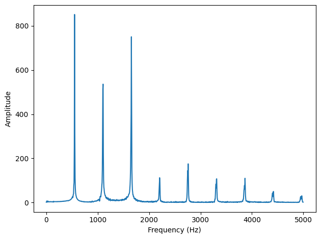

```python
spectrum = segment.make_spectrum()
spectrum.plot(high=5000)
decorate(xlabel='Frequency (Hz)', ylabel='Amplitude')
```

```python
spectrum.peaks()[:6]
```

```
[(851.286051294676, 550.0),
 (750.4194893967242, 1655.0),
 (535.8765203756585, 1105.0),
 (512.9125469185768, 1100.0),
 (432.157194360438, 1660.0),
 (401.1365125794491, 1650.0)]
```

Возьмем треугольный сигнал с такой же основной частотой

```python
from thinkdsp import TriangleSignal

TriangleSignal(freq=550).make_wave(duration=0.2).make_audio()
```

[interactive chart not shown]

Сейчас у сигналов одинаковая воспринимаемая частота - 550

Для анализа применим нашу автокорреляционную функцию

```python
def autocorr_(segment):
    corrs = np.correlate(segment.ys, segment.ys, mode='same')
    N = len(corrs)
    lengths = range(N, N//2, -1)

    half = corrs[N//2:].copy()
    half /= lengths
    half /= half[0]
    return half
```

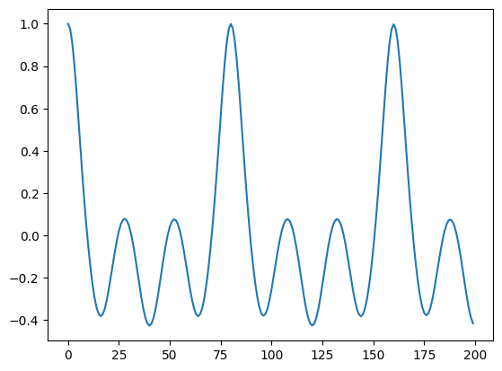

```python
corrs = autocorr_(segment)
plt.plot(corrs[:200])
```

```python
corrs[79], corrs[80], corrs[81]
```

```
(0.9764409474654036, 0.9992407118598035, 0.978030668352388)
```

Пик при lag = 80

```python
print("Fmax = ", estimate_fundamental(segment))
```

```
Fmax =  551.25
```

Уберем основной тон:

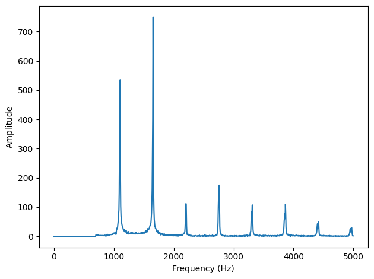

```python
spectrum2 = segment.make_spectrum()
spectrum2.high_pass(700)
spectrum2.plot(high=5000)
decorate(xlabel='Frequency (Hz)', ylabel='Amplitude')
```

```python
segment2 = spectrum2.make_wave()
segment2.make_audio()
```

[interactive chart not shown]

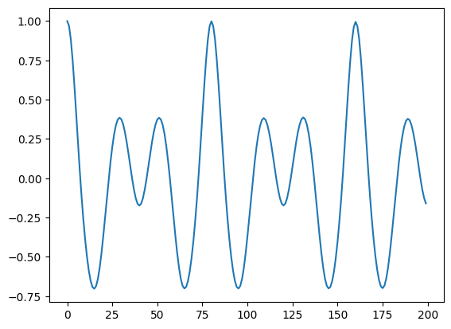

```python
corrs = autocorr_(segment2)
plt.plot(corrs[:200])
```

```python
corrs[79], corrs[80], corrs[81]
```

```
(0.96715203971728, 0.9984968648709538, 0.9691066543157081)
```

Мы слышим ту же ноту, хотя основная частота поменялась. Это связанно с тем что гармоники основной частоты никуда не делись, и они влияют на восприятие